# Assignment 3

Ryan Trieu (dtrieu99@uw.edu)

03/01/2022

**Affiliation**: “INFO-201: Technical Foundations of Informatics - The Information School - University of Washington”

# 1.0 Introduction

According to a study from the National Council on Crime and Delinquency in 2006[^1], the United States has come to rely on jail as a reaction to all sorts of crime in the last 30 years. Minor infractions of parole or probation frequently result in a return to prison. This has resulted in a massive jail system in the United States. The research also mentions interesting facts about incarceration in the United States:

- The United States is home to the world’s largest prison population.
- The incarceration rate in the United States is four times that of the rest of the world.
- Some US states imprison up to six times the number of individuals as countries with similar populations.
- The United States has the highest rate of female incarceration in the world.
- Incarceration rates are not taken into account when calculating crime rates.

# 2.0 Summary Information

County with biggest jail population by race in 2018

| county_name | Asian American / Pacific Islander | Black | Latinx | Native American | White | Other |
| --- | --- | --- | --- | --- | --- | --- |
| Los Angeles County | 90.57 | 5024 | 8728 | 12 | 2579 | 608 |

County with biggest jail admission by race all time

| county_name | Asian American / Pacific Islander | Black | Latinx | Native American | White | Other |
| --- | --- | --- | --- | --- | --- | --- |
| Los Angeles County | 83 | 16354 | 11141 | 79 | 8119 | 3939 |

Total prison admission by race all time

| Asian.American…Pacific.Islander | Black | Latinx | Native.American | White | Other |
| --- | --- | --- | --- | --- | --- |
| 52755 | 5850096 | 2108065 | 188898 | 5579082 | 199575 |

Total jail population by race all time

| Asian.American…Pacific.Islander | Black | Latinx | Native.American | White | Other |
| --- | --- | --- | --- | --- | --- |
| 192596.5 | 7891239 | 3220014 | 240838 | 8814789 | 178066.7 |

Top 10 counties with the highest total jail from ice in 2018

| county_name | state | total_jail_from_ice |
| --- | --- | --- |
| Orange County | CA | 840.00 |
| Irwin County | GA | 829.00 |
| York County | PA | 779.00 |
| Broward County | FL | 677.00 |
| Hudson County | NJ | 608.00 |
| Essex County | NJ | 582.00 |
| Haskell County | TX | 330.55 |
| Bergen County | NJ | 329.00 |
| McHenry County | IL | 298.00 |
| Etowah County | AL | 281.00 |

Top 5 counties in Washington State with highest jail population in 2018

| state | county_name | year | Asian American / Pacific Islander | Black | Latinx | Native American | White | Other | total_jail_pop |
| --- | --- | --- | --- | --- | --- | --- | --- | --- | --- |
| WA | King County | 2018 | 164.54 | 943.95 | 176.27 | 81.00 | 1565.32 | 0.00 | 3060 |
| WA | Pierce County | 2018 | 62.00 | 343.00 | 115.47 | 32.00 | 579.00 | 0.00 | 1222 |
| WA | Yakima County | 2018 | 9.00 | 81.55 | 443.00 | 125.79 | 574.00 | 0.00 | 1150 |
| WA | Snohomish County | 2018 | 19.36 | 111.06 | 51.06 | 82.89 | 709.56 | 5.55 | 1038 |
| WA | Spokane County | 2018 | 16.00 | 134.00 | 0.00 | 71.00 | 766.00 | 0.00 | 1027 |

# 3.0 Trends over time chart

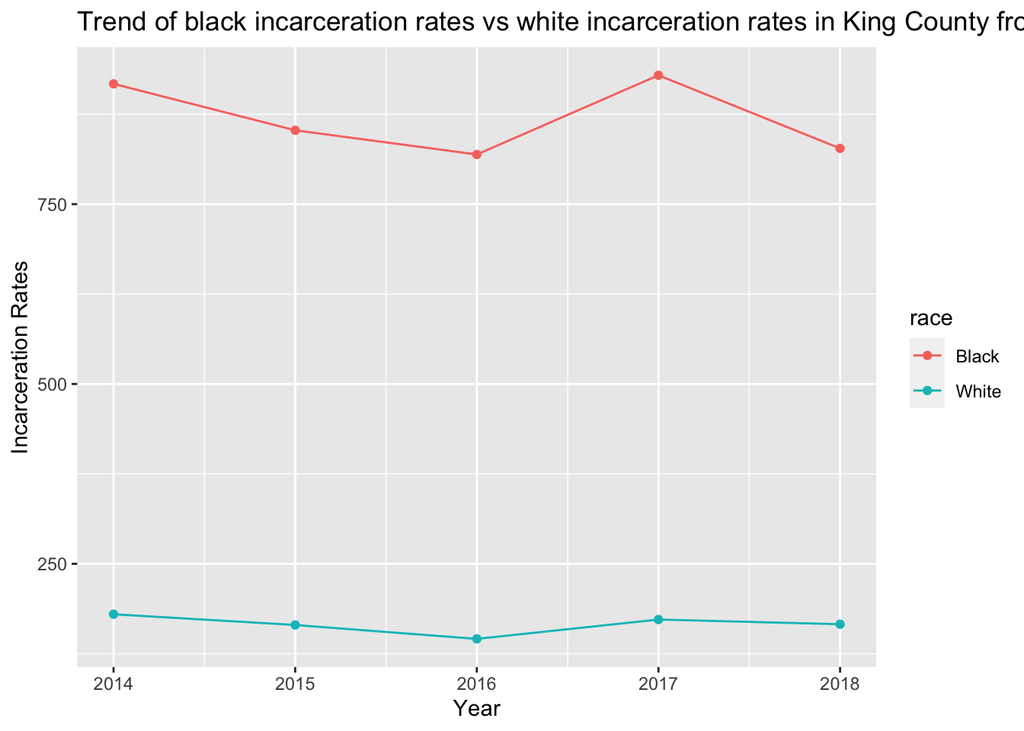

# 4.0 Variable comparison chart

Rated capacity vs Total Jail Admissions Count

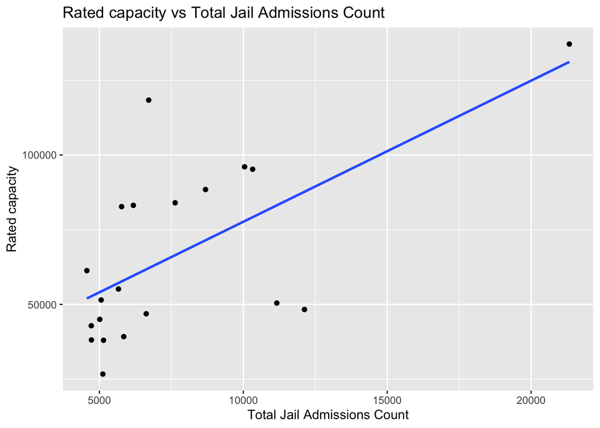

I include this chart to figure out if the rated capacity(the number of people or beds a facility can hold, as set by a rating official)[^2] of a jail affects the total jail admission of that facility. Jail Rated Capacity on Total Jail Admissions Count shows a positive somewhat linear relationship. There is still a lot of variability and the variability does not appear to be constant. There seems to be a relationship between these two variables, but there is not sufficient evidence to conclude that their relationship is causal.

# 5.0 Map

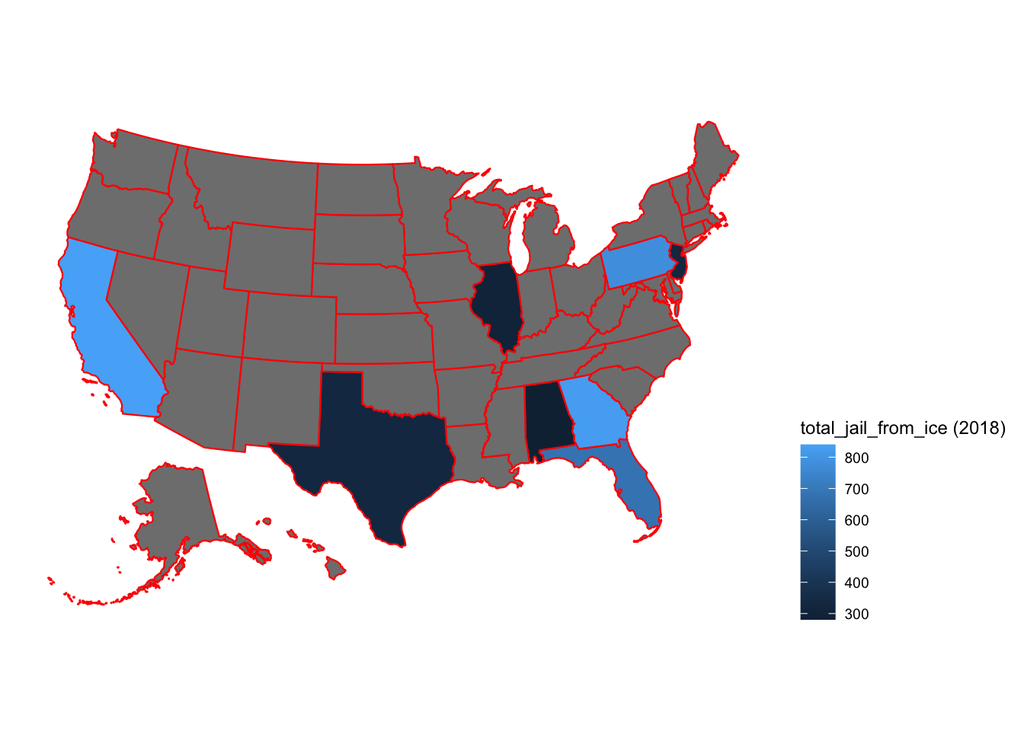

## References

[^1]: [Hartney, Christopher. “US Rates of Incarceration: A Global Perspective.” (2006).](https://www.semanticscholar.org/paper/US-Rates-of-Incarceration%3A-A-Global-Perspective-Hartney/cbcc79e99c3ef29a421d2d306db27bea141e5a0d)
[^2]: [Initiative, P. P. (n.d.). Since you asked: Just how overcrowded were prisons before the pandemic, and at this time of social distancing, how overcrowded are they now? Prison Policy Initiative. Retrieved March 7, 2022](https://www.prisonpolicy.org/blog/2020/12/21/overcrowding/)
[^3]: [Passenger boarding (enplanement) and all-cargo data for U.S. airports – airports. (2022, January 11). Retrieved March 7, 2022](https://www.faa.gov/airports/planning_capacity/passenger_allcargo_stats/passenger/index.cfm?year=)